# NHS-sponsored-Couch to 5k programme

23/12/2021

> **Research Question**  
> Researchers are interested in the psychological factors that make people continue on the programme, and in the effects of taking the programme on health and wellbeing.

#### Question 0: Data Cleaning and Describing

Data has been collected from 131 participants in Edinburgh and Glasglow, all of whom participated NHS-sponsored “Couch to 5k” 9-Week programme across a year in different season. All participants completed questionnaire measuring the psychometric factors of accountability and self-motivation at Week 0, with each item contains 5 questions, scoring 1-7. Upon completing or dropping out the programme, all participants completed another questionnaire measuring self-reported happiness and health based on physiological tests. The scale is from 0-100. Details of the data collected can be found in Table 1

| variables | description |
| --- | --- |
| pptID | Participant ID |
| age | Age (in Years) |
| accountability | psychometric measure of accountability |
| selfmot | psychometric measure of self-motivation |
| health | multi-test health measure |
| happiness | simple happiness scale |
| season | season of the year participants were interviewed in |
| city | city participant was recruited in |
| week_stopped | week of programme participant stopped in (week 9 = completed the programme) |

*Table 1. Details of the couch to 5k data.*

**Problem of the data**

As we look at the data, we found that there are some impossible values in some categories. Therefore, the researcher took some steps to fix the impossible values in the data.

- For age, neither can be <0 nor >100. However, we know that the age variable has no entries < 0 (because of the histogram above).
- For accountability and selfmot, neither can be <0 nor >35.
- For health and happiness, neither can be <0 nor >100.
- For week_stopped, neither can be <0 nor >100.

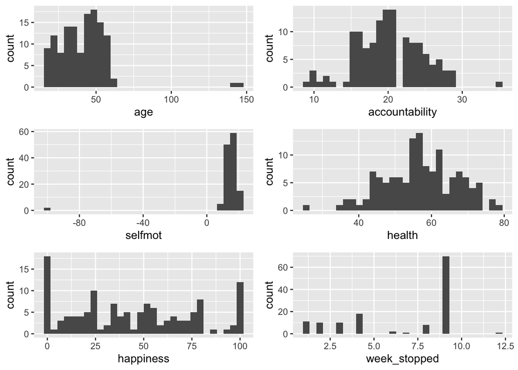

*Figure 1. Visualization of the couch to 5k data.*

**Visualizing the processed data**

After preprocessing the data, the researcher visualises marginal distribution of the data and describes them properly. Note that even though there are some outliers from the below graphs, we decide not to delete them since their value is reasonable and we want to make sure our data is large enough for analysis.

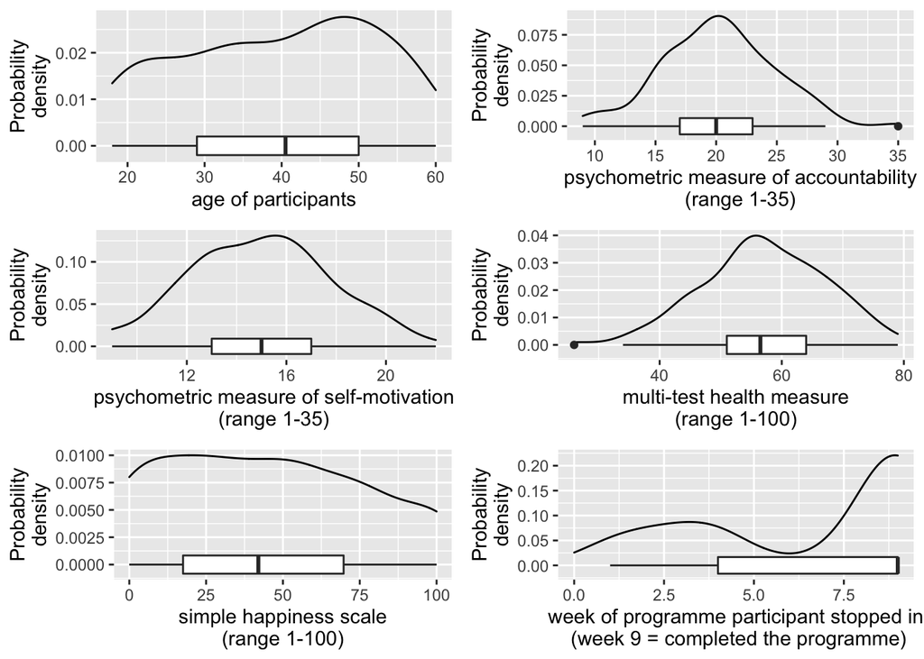

*Figure 2. Marginal distribution plots of age, accountability, self-motivation, health, happiness, and week-stopped.*

- The marginal distribution of age of participants is unimodel with a mean of approximately 41. There is variation in ages (SD = 12.4).
- The marginal distribution of accountability’s score is unimodel with a mean of approximately 20. There is variation in accountability (SD = 4.54).
- The marginal distribution of self-motivation’s score is unimodel with a mean of approximately 15. There is variation in self-motivation (SD = 2.8).
- The marginal distribution of health’s score is unimodel with a mean of approximately 57. There is variation in health (SD = 10).
- The marginal distribution of happiness is unimodel with a mean of approximately 45. There is variation in health (SD = 31.7).
- The marginal distribution of week participants stopped in looks like bimodel with a mean of approximately 6.51 weeks. There is variation in health (SD = 3.08).

#### Question 1: General Check

##### Question 1a

> In an earlier nationwide survey, researchers found that 45% of participants abandoned the programme before the halfway point in week 5, and a further 10% gave up before the end of the programme. Is the data in the sample I have been given in line with data from the earlier survey?

To investigate the question, we performed a χ2 goodness of fit test to assess the extent to which our sample of data conform to the theorised distribution of the time people abandoned the programme. Our hypothesis is as followed.

- **H<sub>0</sub>** : The proportion of participants abandoned the programme in stopped before week 5, stopped after week 5, completed, is 45%, 10%, 45% respectively.
- **H<sub>1</sub>** : At least one of the proportions in the null hypothesis is false.
- **$\alpha$** = 0.05

```
##
##  Chi-squared test for given probabilities
##
## data:  table(week_categories)
## X-squared = 4, df = 2, p-value = 0.1
```

> **Results:**  
> Since p-value is larger than the significance level(alpha = 0.05), we fail to reject the null hypothesis that observed data are consistent with the specified distribution. Therefore, we conclude that our observed value is in line with the data from the earlier survey.

##### Question 1b

> Using the same three categories (stopped before week 5, stopped after week 5, completed), examine whether the patterns of attrition rates differ by city.

In this question, we first perform a χ2 test of independence to assess whether the patterns of attrition rates differ by city. However, a warning “Chi-squared approximation may be incorrect” appear since the contingency table (Table 1.)shown below confirms that there is at least one cell below 5. Therefore, we use the Fisher’s exact test instead of the Chi-square test because our sample is small (in this case the p-value is exact and is not an approximation.)

|  | Edinburgh | Glasgow |
| --- | --- | --- |
| Weeks<5 | 38.45 | 10.55 |
| 5<Weeks<9 | 8.63 | 2.37 |
| Weeks=9 | 54.92 | 15.08 |

*Table 1. The expected value for week catagories and city.*

```
##
##  Fisher's Exact Test for Count Data
##
## data:  table(week_categories, couchto5k$city)
## p-value = 0.4
## alternative hypothesis: two.sided
```

> **Results:**  
> After applying Fisher’s exact test, the p-value is 0.4, which is still larger than the significance level(alpha = 0.05). Therefore, we cannot say the patterns of attrition rates differ by city.

##### Question 1c

> Do the average ages of participants who commenced the programme differ by city?

```
##
##  Welch Two Sample t-test
##
## data:  couchto5k$age[couchto5k$city == "Edinburgh"] and couchto5k$age[couchto5k$city == "Glasgow"]
## t = 2, df = 48, p-value = 0.1
## alternative hypothesis: true difference in means is not equal to 0
## 95 percent confidence interval:
##  -0.782  9.142
## sample estimates:
## mean of x mean of y
##      40.4      36.2
```

> **Results:**  
> In this question, we perform a t-test to assess whether the average ages of participants who commenced the programme differ by city. By evaluating the p-value, we fail to reject our null hypothesis that there is no relationship between the average ages of participants and the city they were recruited in. In other words, the result are due to chance and are not significant in terms of supporting the idea that average ages differ from city.

#### Question 2: Happiness

##### Question 2a

> Are participants’ happiness ratings affected by the season they were interviewed in? Describe the way in which season influences happiness outcomes.

We first plotted a boxplot to roughly observe the happiness ratings in different season, as shown in Figure 3. We noticed that the mean of happiness is slightly higher in spring and winter, which might indicate that the participants lift their mood when they were recruited in those season. On top of that, the interquartile range of winter is comparatively shorter than the rest, suggesting that participants have score their happiness rating higher in winter than in other seasons.

Instead of using correlation to assess whether happiness and season are related, we applied One-way ANOVA to see their relationship since season (independent variable) is a categorical variable and happiness (dependent variable) is continuous variable. We assumed that the observations are independent of each other. If any group differs significantly from the overall group mean, then the ANOVA will report a statistically significant result.

- **H<sub>0</sub>** : There is no difference among group means.
- **H<sub>1</sub>** : At least one pair of means is different.
- **$\alpha$** = 0.05

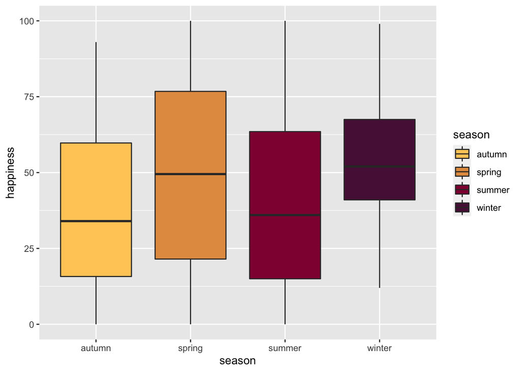

*Figure 3. The distribution of happiness ratings in different season.*

```
##                   Df Sum Sq Mean Sq F value Pr(>F)
## couchto5k$season   3   3593    1198     1.2   0.31
## Residuals        126 126068    1001
```

> **Results:**  
> From the result, we see that F-value is 1.2 and it has a p-value of 0.314 which is not smaller than $\alpha$. Therefore, we fail to reject the null hypothesis, meaning that all means are the same; the differences in season are due to random variation. Happiness does not affected by the season at all.

##### Question 2b

> Accounting for any effects you discovered in (2a), is happiness affected by age?

Figure 4. illustrates the relationship between the happiness ratings and participants’ age, which looks quite low since the dots scatter over the graph without showing any tendency. Next, we use correlation to further check the association between these two numeric variables.

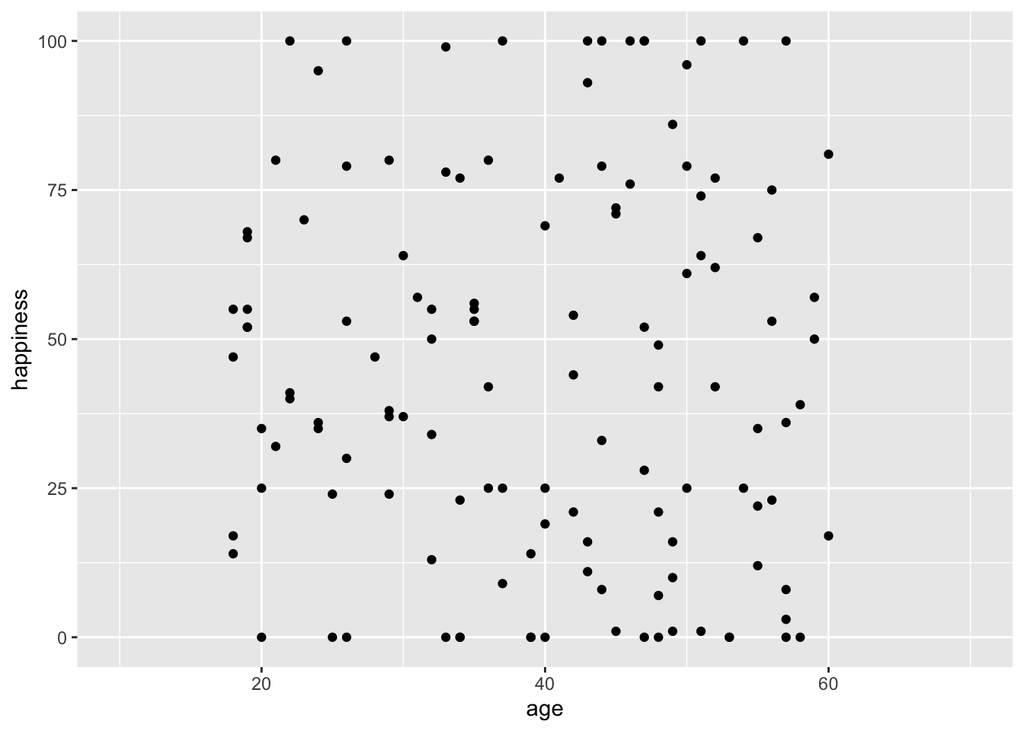

*Figure 4. The relationship between the happiness ratings and participants’ age.*

```r
cor(x = couchto5k$happiness, y = couchto5k$age, use = "complete.obs")
```

```
## [1] -0.0325
```

> **Results:**  
> As we can see from the Figure 4. and the value of correlation, there is no evidence that the happiness is affected by participants’ age. Since r ≈ 0, it means that there is no linear association between the two variables. The higher/lower values of the happiness do not tend to occur with higher/lower values of the ages.

##### Question 2c

> Pick a specific baseline model and justify why you are using this.

Since both season and age do not significantly affect the happiness ratings, we investigated whether there was other variables that might associate with the happiness in order to build a baseline model.  
After examining other variables such as *accountability*, *selfmot*, and *city*, we decided to **choose *selfmot* as a baseline model** since it is the only variable that shows some relationship with the happiness rating. In this case, the slope, 3.64, has a standard error of 0.96. Then, we perform a test against the null hypothesis that there is no linear association between self-motivation and the happiness rating. As we can see from the below result, the p-value is 0.00023, which is a small value, meaning that we have strong evidence against the null hypothesis.

```
##             Estimate Std. Error t value Pr(>|t|)
## (Intercept)    -9.80      14.58  -0.673 0.502489
## selfmot         3.64       0.96   3.796 0.000229
```

**Check the residual plots to ensure trustworthy regression results**

After fitting a regression model, we check the residual plots (Figure 5) to see whether we violate the assumptions.

> **Results:**  
> The model doesn’t look bad.  
> - The top left plot (residuals vs fitted) shows a reasonably straight red line, indicating that the mean of the residuals is close to zero across the fitted values.  
> - The top right plot (QQ plot of residuals) shows that the residuals are fairly close to the dotted line with only a few residuals stray from the line quite a bit near the head and tails. Overall, it indicates they follow close to a normal distribution.  
> - The bottom left plot (scale location plot) allows us to examine the extent to which the variance of the residuals changes accross the fitted values. The straight red line indicates reasonably constant variance.  
> - The bottom right plot (residuals vs leverage plot) allows us to identify influential observations in a regression model. In this case, there are no influential cases.

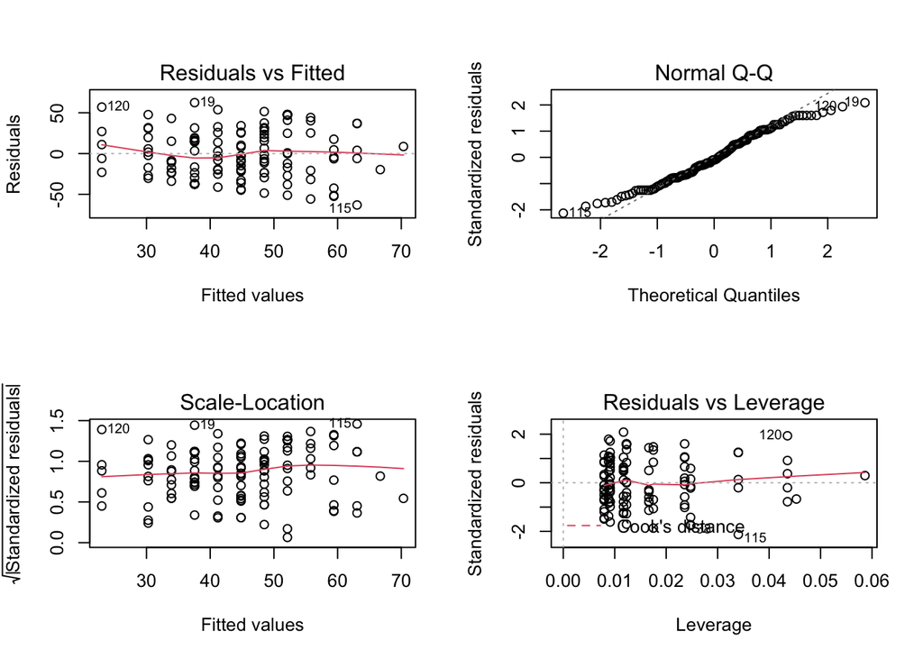

*Figure 5. The residual plot for the regression model of happiness and self-motivation.*

#### Question 3:Happiness and Health

##### Question 3a

> Building on your baseline model, are participants’ happiness ratings affected by whether or not they completed the programme? Describe the way in which programme completion influences happiness outcomes.

To evaluate this hypothesis, we are going to fit the following model:

$Happiness = b_0 + b_1⋅Selfmot + b_2⋅Complete +\epsilon$

We fit the linear model specified by the formula above using lm( ). In this situation,

```
##             Estimate Std. Error t value Pr(>|t|)
## (Intercept)   -14.56      14.61  -0.997 3.21e-01
## selfmot         4.38       1.02   4.297 3.48e-05
## complete      -11.34       5.73  -1.979 5.00e-02
```

- $\hat{\beta}_0 = -14.56$, the estimated average happiness score associated with zero week of completion and zero self-motivation score.
- $\hat{\beta}_1 = 4.38$, the estimated increase in happiness score associated with self-motivation score, holding the completion week.
- $\hat{\beta}_2 = -11.34$, the estimated increase in happiness score associated with one week increase in completed the programme, holding the number of self-motivation score.

**Check the residual plots to ensure trustworthy regression results**

Again, after fitting a regression model, we check the residual plots (Figure 6) to see whether we violate the assumptions.  
According to the below four plots, our model does not look bad. The residuals vs fitted plot shows a reasonably straight red line, indicating that the model’s predictions are correct on average. QQ plot also indicates that residuals follow close to a normal distribution. The horizontal line with randomly spread points in the scale-location plot also suggest that residuls do not violate the assumptions of equal variance.

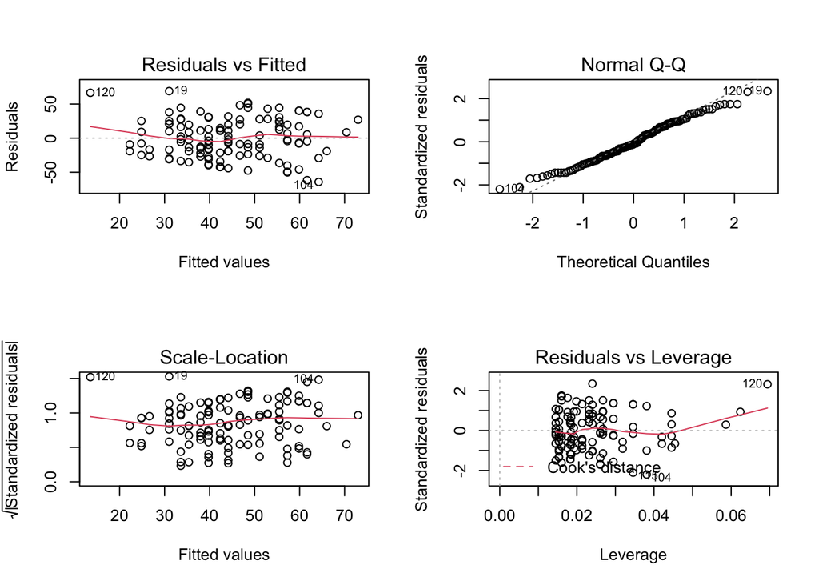

*Figure 6. The residual plot for the regression model $Happiness = b_0 + b_1⋅Selfmot + b_2⋅Complete +\epsilon$*

Next, we used partial F-test to compare whether our linear regression model(with completion variable) provides a better fit to the data than a model that contains a subset of the predictor variables in the overall regression model. In other words, we compared the following two models:

$Happiness = b_0 + b_1⋅Selfmot + b_2⋅Complete +\epsilon$

$Happiness = b_0 + b_1⋅Selfmot + \epsilon$

This test uses the following null and alternative hypotheses:

- **H<sub>0</sub>** : All coefficients removed from the full model are zero.
- **H<sub>1</sub>** : At least one of the coefficients removed from the full model is non-zero.
- **$\alpha$** = 0.05

```
## Analysis of Variance Table
##
## Model 1: happiness ~ selfmot + complete
## Model 2: happiness ~ selfmot
##   Res.Df    RSS Df Sum of Sq    F Pr(>F)
## 1    123 109190
## 2    124 112669 -1     -3478 3.92   0.05 *
## ---
## Signif. codes:  0 '***' 0.001 '**' 0.01 '*' 0.05 '.' 0.1 ' ' 1
```

> **Results:**  
> As we can see from the output, the F test-statistic from the ANOVA is 3.92 and the corresponding p-value is 0.05. Since this p-value is less than or equal to 0.05, we will reject the null hypothesis, meaning that we have sufficient evidence to say that the predictor variables complete is statistically significant. In other words, adding completion to the regression model indeed improve the fit of the model. This argument can also be supported by looking at the adjusted r square in the two model. Adjusted r square increases when adding completion as an independent variable, the value is 0.118. For baseline model, the value of adjusted r square is only 0.097.

##### Question 3b

> Building on the analysis in (3a), is happiness additionally affected by the “health metric”?

In this question, we compare the following model:

$Happiness = b_0 + b_1⋅Selfmot + b_2⋅Complete + b_3⋅Health + \epsilon$

$Happiness = b_0 + b_1⋅Selfmot + + b_2⋅Complete + \epsilon$

First, we build another multiple linear model that includes health explanatory variable. And since we are analyzing whether health is another factor that affects happiness comparing to not adding it, we use partial F-test to make the comparison.

```
##             Estimate Std. Error t value Pr(>|t|)
## (Intercept)  -34.438     21.431   -1.61 1.11e-01
## complete     -11.411      5.713   -2.00 4.80e-02
## selfmot        4.436      1.017    4.36 2.72e-05
## health         0.334      0.264    1.26 2.08e-01
```

```
## Analysis of Variance Table
##
## Model 1: happiness ~ complete + selfmot + health
## Model 2: happiness ~ selfmot + complete
##   Res.Df    RSS Df Sum of Sq   F Pr(>F)
## 1    122 107777
## 2    123 109190 -1     -1413 1.6   0.21
```

> **Results:**  
> We can approach the problem in two different angle. First, the summary of the model $Happiness = b_0 + b_1⋅Selfmot + b_2⋅Complete + b_3⋅Health + \epsilon$ shows the p-value for health coefficients is 0.208, which is greater than 0.05. This indicates that there is no association between the changes in the health score and the shifts in the happiness. In other words, there is insufficient evidence to conclude that there is an effect at the population level. Second, the p-value in the result of partial F-test is also larger than 0.05, which supports the argument that the association between health and happiness is not significant.

##### Question 3c

> It’s been hypothesised that the effects of good health are amplified by the feeling of acting healthily, such that the happiness of participants who got further along the programme might be more affected by the health metric than that of those who stopped earlier. Building on the model in (3b), can you test this hypothesis?

To address the question, we are going to fit the following model:

$where \space \epsilon \sim \text{N}(0, \sigma) \space independently$

That means we are estimating the extent to which the effect of health on happiness is different across the values of week stopped.

```
##                     Estimate Std. Error t value Pr(>|t|)
## (Intercept)           113.06    42.1298    2.68 8.30e-03
## week_stopped          -20.95     5.2728   -3.97 1.21e-04
## selfmot                 4.28     0.9554    4.48 1.73e-05
## health                 -2.22     0.7121   -3.11 2.32e-03
## week_stopped:health     0.35     0.0912    3.84 1.96e-04
```

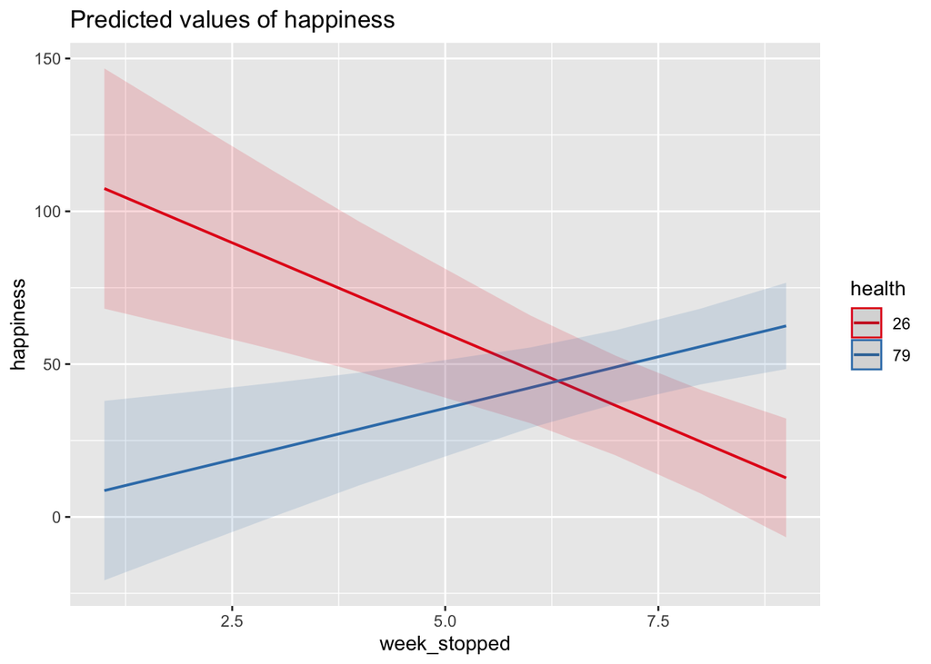

*Figure 7. Multiple regression model: happiness ~ week_stopped + selfmot + health + health*week_stopped. The interaction between health and week_stopped affected the score of happiness. *

> **Results:**  
> The p-values(=0.000196) in the output above tell us that the interaction effect (Week_stopped/Health) is statistically significant. Consequently, we know that the happiness we derive from the week stopped depends on the health score.  
> Figure 7. shows the relationship between week stopped and happiness changes direction based on the health. The crossed lines on the graph suggest that there is an interaction effect, which the significant p-value for the Week_stopped/Health term confirms. For high health score, there is a positive between week stopped and happiness while for low health score it is a negative relationship.

##### Question 3d

> What can we conclude about the various causes of happiness in our data? Write a brief description of the effects in the model, such as you might find in an academic paper.

|  | happiness |  |  |
| --- | --- | --- | --- |
| Predictors | Estimates | CI | p |
| (Intercept) | 113.06 | 29.65 – 196.47 | **0.008** |
| week stopped | -20.95 | -31.39 – -10.51 | **<0.001** |
| selfmot | 4.28 | 2.38 – 6.17 | **<0.001** |
| health | -2.22 | -3.63 – -0.81 | **0.002** |
| week stopped * health | 0.35 | 0.17 – 0.53 | **<0.001** |
| Observations | 126 |  |  |
| R<sup>2</sup> / R<sup>2</sup> adjusted | 0.218 / 0.192 |  |  |

*Table 2. Summary of our multiple regression model: happiness ~ week_stopped + selfmot + health + health*week_stopped. *

#### Question 4

| pptID | age | accountability | selfmot | health | happiness | season | city | week_stopped |
| --- | --- | --- | --- | --- | --- | --- | --- | --- |
| ID26 | 51 | 22 | 20 | 57 | 100 | spring | Edinburgh | 9 |
| ID42 | 47 | 25 | 20 | 63 | 100 | spring | Edinburgh | 9 |
| ID63 | 51 | 19 | 19 | 56 | 64 | spring | Edinburgh | 9 |
| ID86 | 59 | 21 | 20 | 59 | 57 | spring | Edinburgh | 9 |
| ID96 | 57 | 25 | 19 | 50 | 8 | spring | Edinburgh | 9 |

*Table 3. The first 5 rows of participants who complete the programme.*

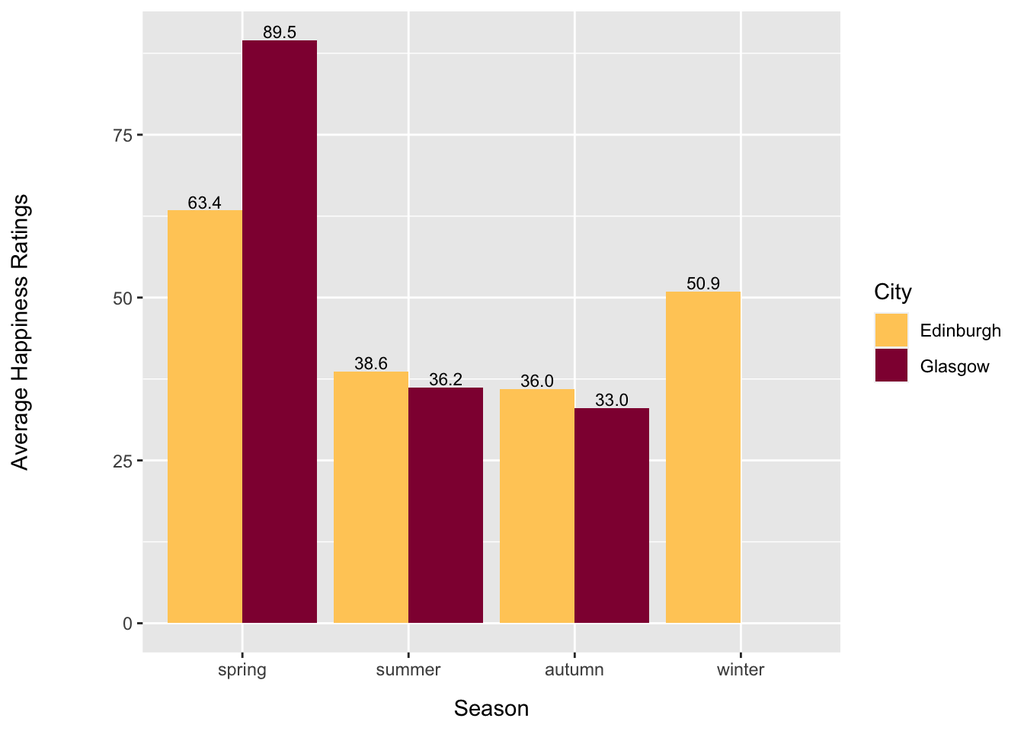

*Figure 8. The average happiness ratings grouped by season and city.*

#### Question 5: Predictors of Drop-out

##### Question 5a/5b

> Build a model that predicts the likelihood of dropping out (at all). And briefly describe the effects in your model as you would in an academic paper.

We built a model for the prediction of ydropping out the programme based on several variables, including self-motivation, age, and health. The result is shown below. Since the coefficients of the model is interpret in log-odds, which is not intuitive, we translated them back into odds by applying exponential (shown at the second chunk below).

```
##
## Call:
## glm(formula = complete2 ~ selfmot + age + health, family = "binomial",
##     data = couchto5k2)
##
## Deviance Residuals:
##    Min      1Q  Median      3Q     Max
## -1.885  -0.980  -0.507   1.016   1.892
##
## Coefficients:
##             Estimate Std. Error z value Pr(>|z|)
## (Intercept)   8.1949     2.5684    3.19  0.00142 **
## selfmot      -0.3059     0.0809   -3.78  0.00016 ***
## age          -0.0442     0.0214   -2.06  0.03913 *
## health       -0.0372     0.0255   -1.46  0.14389
## ---
## Signif. codes:  0 '***' 0.001 '**' 0.01 '*' 0.05 '.' 0.1 ' ' 1
##
## (Dispersion parameter for binomial family taken to be 1)
##
##     Null deviance: 173.53  on 125  degrees of freedom
## Residual deviance: 151.20  on 122  degrees of freedom
## AIC: 159.2
##
## Number of Fisher Scoring iterations: 3
```

```
## (Intercept)     selfmot         age      health
##    3622.449       0.736       0.957       0.963
```

| selfmot | age | health | logodds | odds | probs |
| --- | --- | --- | --- | --- | --- |
| 9 | 40 | 57 | 1.553 | 4.727 | 0.825 |
| 14 | 40 | 57 | 0.024 | 1.024 | 0.506 |
| 18 | 40 | 57 | -1.200 | 0.301 | 0.232 |

*Table 4. Probability of dropping out the programme. The three individuals have different self-motivation score but with the same age and health score.*

> **Results:**  
> In question 5a, we build a model to predict the likelihood of dropping out. The choice of predictive variables is carried out by stepwise regression method. In each step, a variable is considered for addition to or subtraction from the set of explanatory variables based on some criterion (Investopedia). Results showed that holding age and health constant, with one unit increase in self-motivation, chances of the participants’ dropping out the programme might decrease ($\beta$=-0.305, SE = 0.08, p <.01). For example, we take three participants who have the same age and health score but different self-motivation score. The probability of dropping out the programme decreases if they have higher self-motivation score, with the person who scores himself/herself 9 in self-motivation have 0.825 probability of dropping out; whereas the person who has 18 scores in self-motivation only have 0.232 probability of dropping out the programme.

##### Question 5c

> Draw a graph representing the probability of quitting as a function of how self motivated participants were.

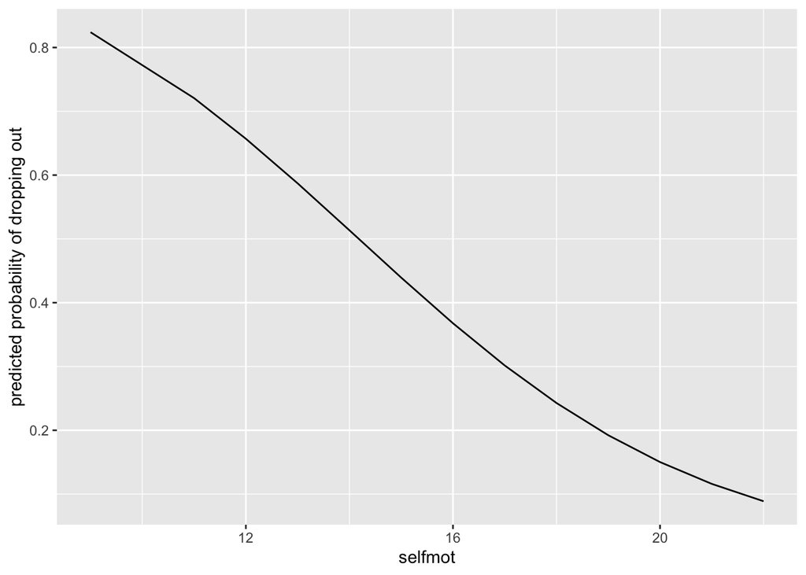